# White Wine Quality EDA by Prithwish Ganguly

This report explores a dataset containing quality and attributes for 4898 white wines. This dataset is a variant of the Portuguese “Vinho Verde” wine.

## Univariate Plots Section

```
## [1] 4898   12
```

```
## 'data.frame':    4898 obs. of  12 variables:
##  $ fixed.acidity       : num  7 6.3 8.1 7.2 7.2 8.1 6.2 7 6.3 8.1 ...
##  $ volatile.acidity    : num  0.27 0.3 0.28 0.23 0.23 0.28 0.32 0.27 0.3 0.22 ...
##  $ citric.acid         : num  0.36 0.34 0.4 0.32 0.32 0.4 0.16 0.36 0.34 0.43 ...
##  $ residual.sugar      : num  20.7 1.6 6.9 8.5 8.5 6.9 7 20.7 1.6 1.5 ...
##  $ chlorides           : num  0.045 0.049 0.05 0.058 0.058 0.05 0.045 0.045 0.049 0.044 ...
##  $ free.sulfur.dioxide : num  45 14 30 47 47 30 30 45 14 28 ...
##  $ total.sulfur.dioxide: num  170 132 97 186 186 97 136 170 132 129 ...
##  $ density             : num  1.001 0.994 0.995 0.996 0.996 ...
##  $ pH                  : num  3 3.3 3.26 3.19 3.19 3.26 3.18 3 3.3 3.22 ...
##  $ sulphates           : num  0.45 0.49 0.44 0.4 0.4 0.44 0.47 0.45 0.49 0.45 ...
##  $ alcohol             : num  8.8 9.5 10.1 9.9 9.9 10.1 9.6 8.8 9.5 11 ...
##  $ quality             : int  6 6 6 6 6 6 6 6 6 6 ...
```

```
##  volatile.acidity  citric.acid     residual.sugar     chlorides
##  Min.   :0.0800   Min.   :0.0000   Min.   : 0.600   Min.   :0.00900
##  1st Qu.:0.2100   1st Qu.:0.2700   1st Qu.: 1.700   1st Qu.:0.03600
##  Median :0.2600   Median :0.3200   Median : 5.200   Median :0.04300
##  Mean   :0.2782   Mean   :0.3342   Mean   : 6.391   Mean   :0.04577
##  3rd Qu.:0.3200   3rd Qu.:0.3900   3rd Qu.: 9.900   3rd Qu.:0.05000
##  Max.   :1.1000   Max.   :1.6600   Max.   :65.800   Max.   :0.34600
##  free.sulfur.dioxide total.sulfur.dioxide    density             pH
##  Min.   :  2.00      Min.   :  9.0        Min.   :0.9871   Min.   :2.720
##  1st Qu.: 23.00      1st Qu.:108.0        1st Qu.:0.9917   1st Qu.:3.090
##  Median : 34.00      Median :134.0        Median :0.9937   Median :3.180
##  Mean   : 35.31      Mean   :138.4        Mean   :0.9940   Mean   :3.188
##  3rd Qu.: 46.00      3rd Qu.:167.0        3rd Qu.:0.9961   3rd Qu.:3.280
##  Max.   :289.00      Max.   :440.0        Max.   :1.0390   Max.   :3.820
##    sulphates         alcohol         quality
##  Min.   :0.2200   Min.   : 8.00   Min.   :3.000
##  1st Qu.:0.4100   1st Qu.: 9.50   1st Qu.:5.000
##  Median :0.4700   Median :10.40   Median :6.000
##  Mean   :0.4898   Mean   :10.51   Mean   :5.878
##  3rd Qu.:0.5500   3rd Qu.:11.40   3rd Qu.:6.000
##  Max.   :1.0800   Max.   :14.20   Max.   :9.000
```

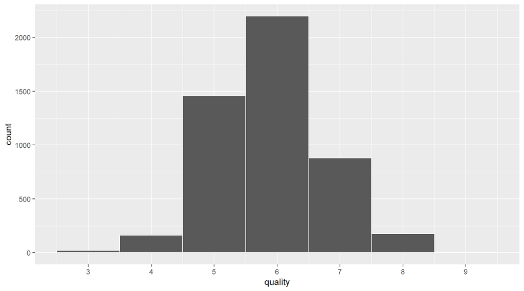

So, quality is measured in discrete values and has a near perfect normal distribution. The quality of wines in this dataset ranging between 3 and 9 and most wines have a rating of 6.

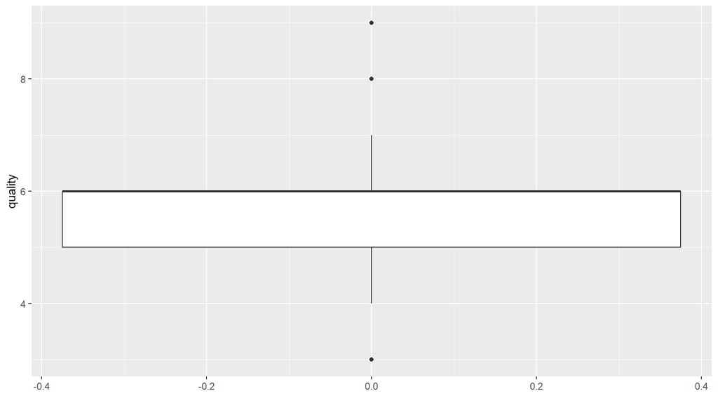

We can observe here that, there are easily more ‘normal quality’ wines that ‘poor quality’ or ‘excellent quality’. The outliers at the lower end being the ‘poor quality’ wines and upper end being the ‘excellent quality’. It would be interresting to group the wines based on these 3 categories rather than their discrete values.

```
##
##    3    4    5    6    7    8    9
##   20  163 1457 2198  880  175    5
```

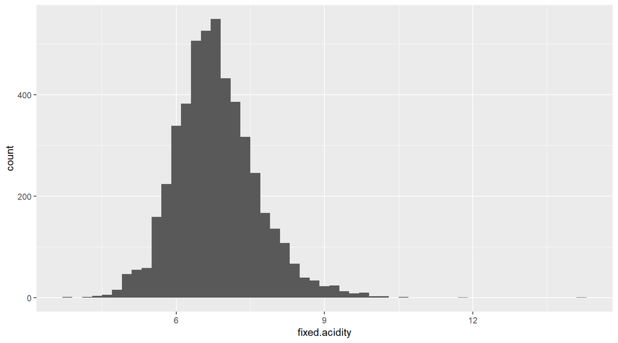

The fixed.acidity distribution is normally distributed about a mean of 6.855.

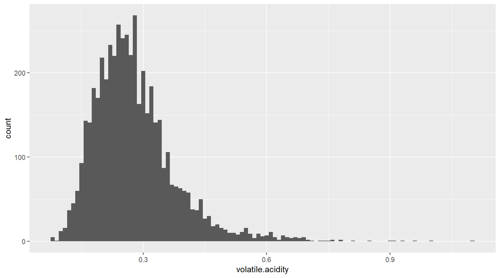

```
##    Min. 1st Qu.  Median    Mean 3rd Qu.    Max.
##  0.0800  0.2100  0.2600  0.2782  0.3200  1.1000
```

The volatile.acidity distribution looks about normal about the mean 0.2782.

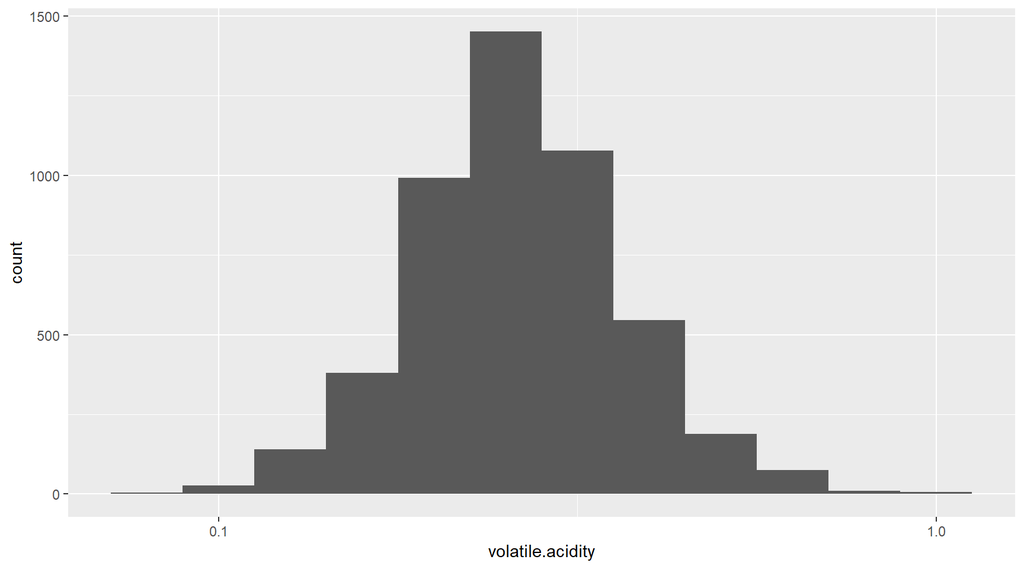

I transformed the volatile.acidity data to look at its distribution and its transformation perfectly normally distributed.

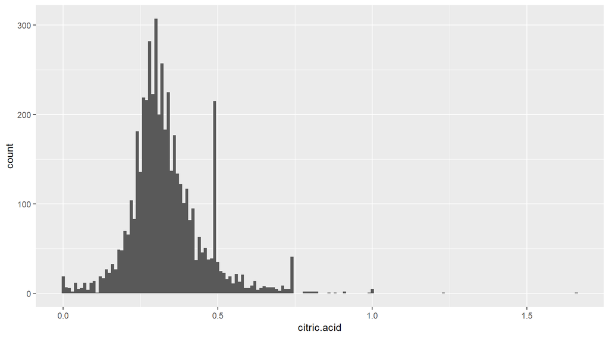

```
##    Min. 1st Qu.  Median    Mean 3rd Qu.    Max.
##  0.0000  0.2700  0.3200  0.3342  0.3900  1.6600
```

The distribution looks normal about a mean of 0.3342 but there is a wierd peak at 0.5.

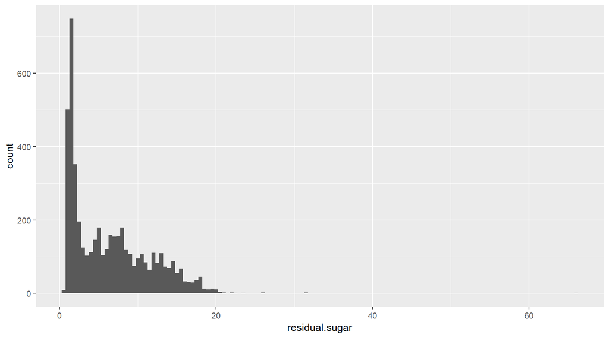

The residual sugar has a long right tail, it would be interesting to transform it to a log scale

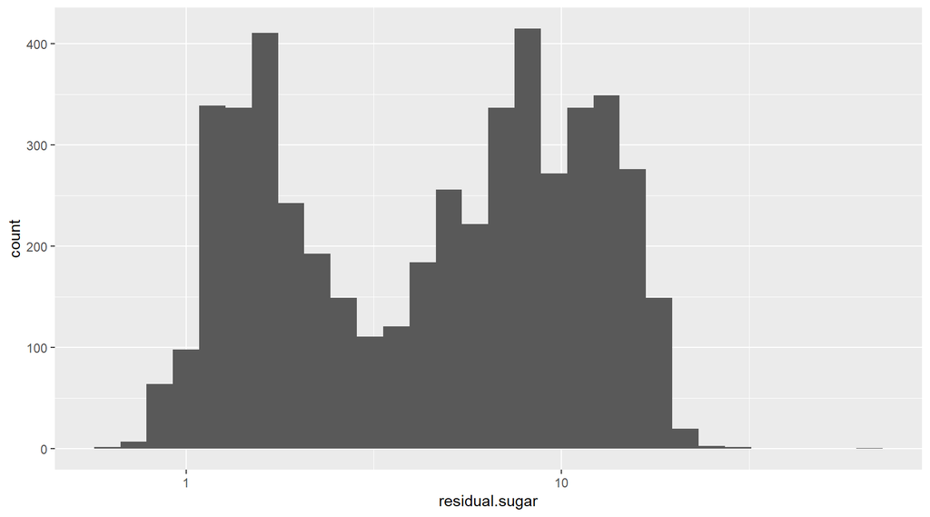

This transformation of ‘residual.sugar’ appears to be bimodal in nature, peaking first at around 1.75 then again at around 9.

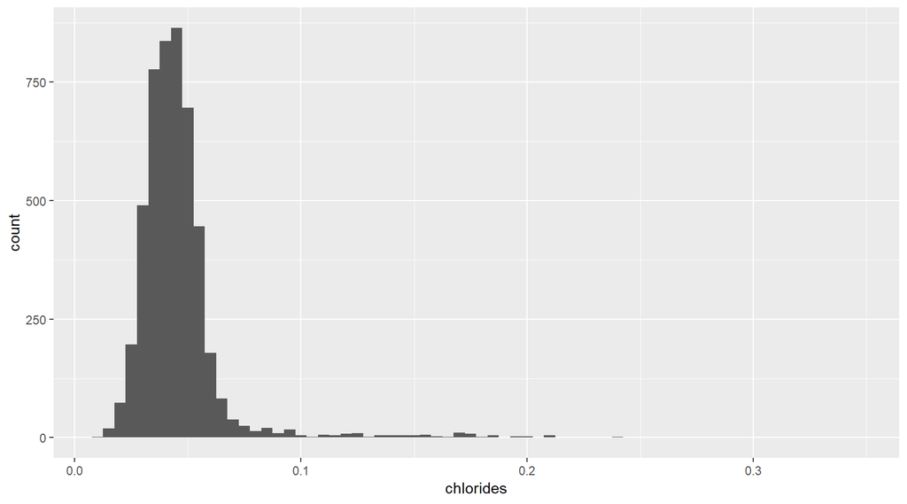

```
##    Min. 1st Qu.  Median    Mean 3rd Qu.    Max.
## 0.00900 0.03600 0.04300 0.04577 0.05000 0.34600
```

The chlorides distribution is also normal but has a lot of outliers as show below.

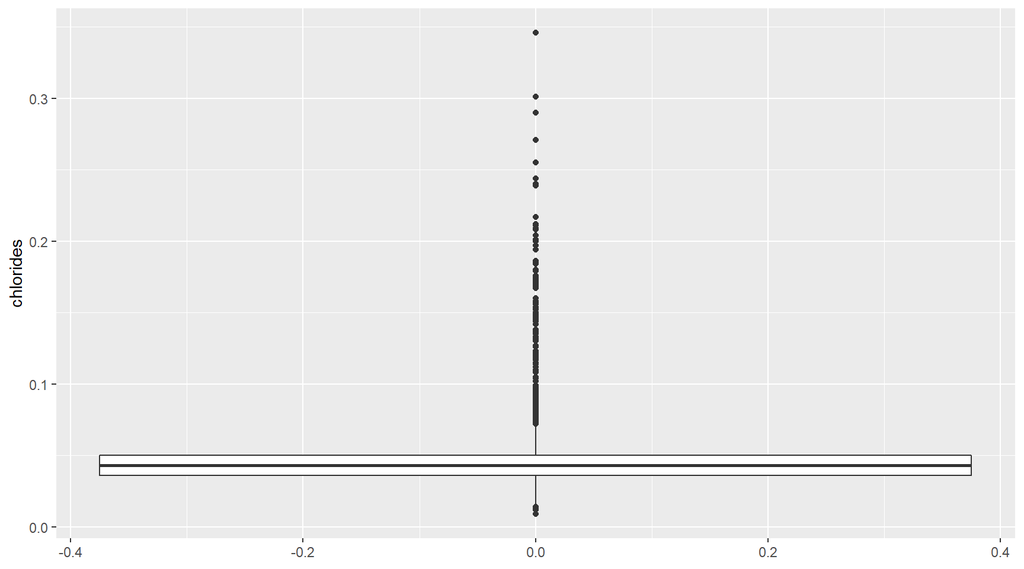

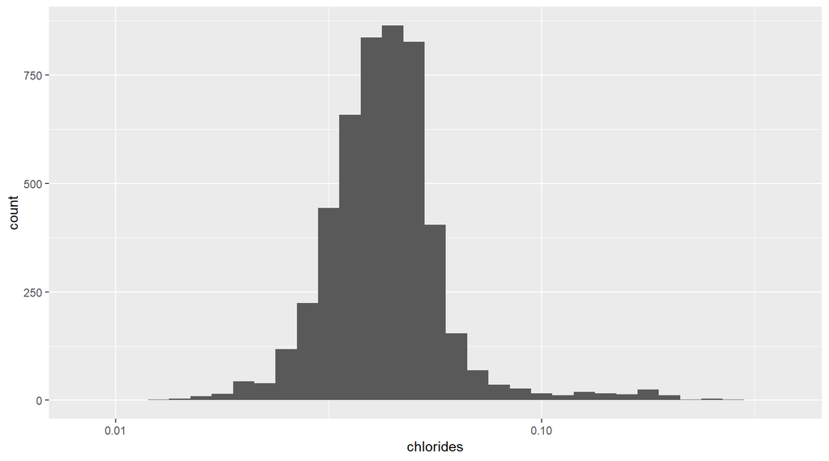

The log transformation of chlorides is also normally distributed.

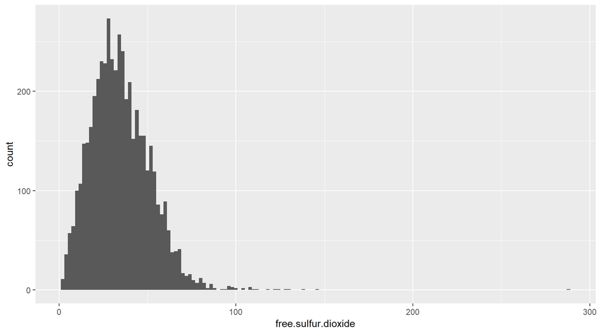

```
##    Min. 1st Qu.  Median    Mean 3rd Qu.    Max.
##    2.00   23.00   34.00   35.31   46.00  289.00
```

The free.sulfur.dioxide distribution is also normal about a mean of 35.31. There are quite a few outliers but there is one particularly high one at 289. I am really interested by the one wine that had 289 free.sulfur.dioxide.

```
##      fixed.acidity volatile.acidity citric.acid residual.sugar chlorides
## 4746           6.1             0.26        0.25            2.9     0.047
##      free.sulfur.dioxide total.sulfur.dioxide density   pH sulphates
## 4746                 289                  440 0.99314 3.44      0.64
##      alcohol quality
## 4746    10.5       3
```

Oh, this belonged to one of the low quality wines! This wine also has the highest total.sulfur.dioxide in our dataset which in itself is another huge outlier. Maybe presence of high quantities of sulfur dioxide reduces the quality of wine? Will have to look into this later!

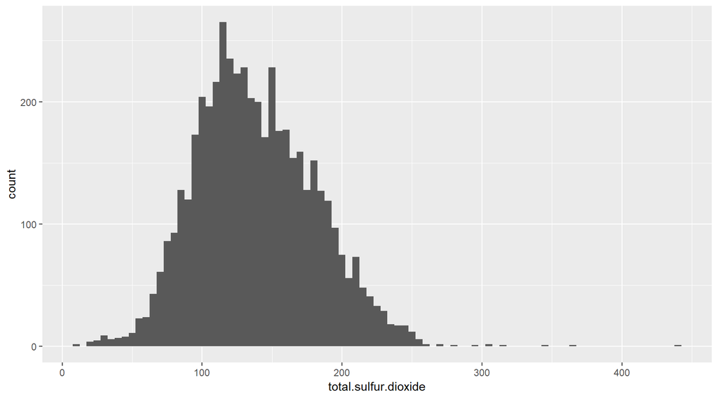

```
##    Min. 1st Qu.  Median    Mean 3rd Qu.    Max.
##     9.0   108.0   134.0   138.4   167.0   440.0
```

Again total.sulfur.dioxide also seems to be normally distributed with about a mean of 138.4. Now by definition, total.sulfur.dioxide = free.sulfur.dioxide + bound.sulfur.dioxide. I will now make a variable called bound.sulfur.dioxide = total.sulfur.dioxide - free.sulfur.dioxide

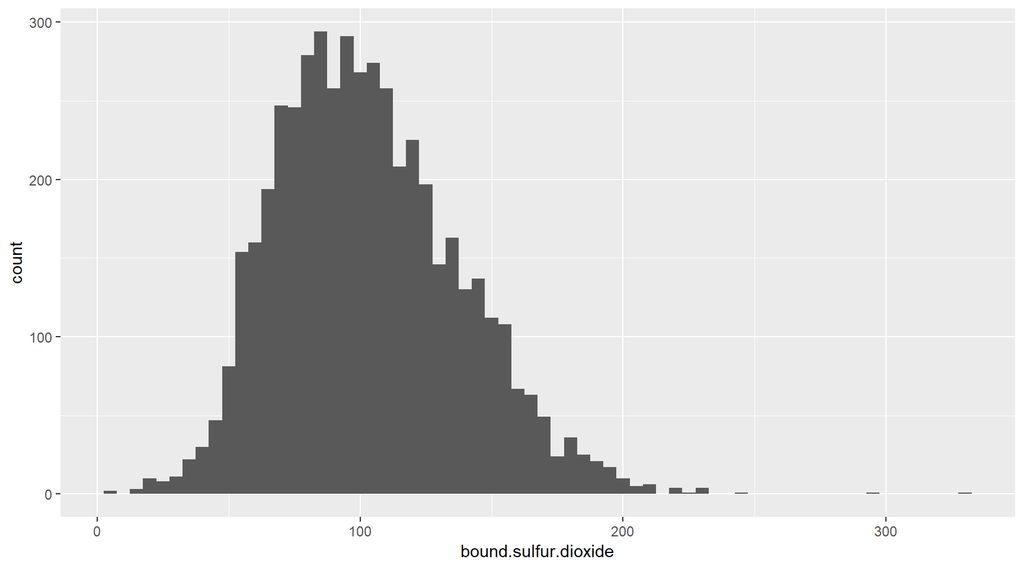

```
##    Min. 1st Qu.  Median    Mean 3rd Qu.    Max.
##     4.0    78.0   100.0   103.1   125.0   331.0
```

Bound.sulfur.dioxide is also normally distributed and looks similar to the other sulfur dioxide distributions. The mean of this distribution is 103.1.

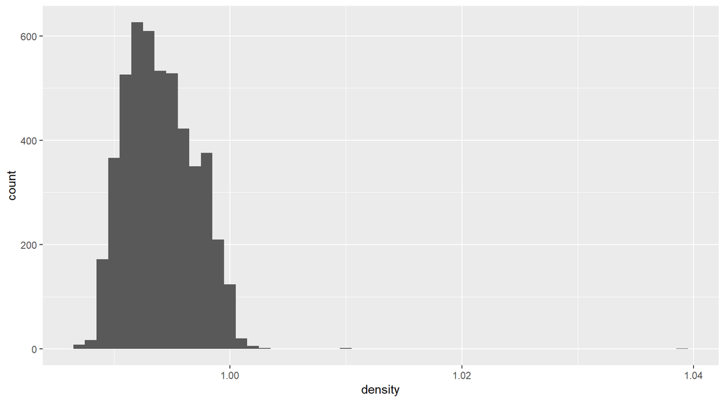

```
##    Min. 1st Qu.  Median    Mean 3rd Qu.    Max.
##  0.9871  0.9917  0.9937  0.9940  0.9961  1.0390
```

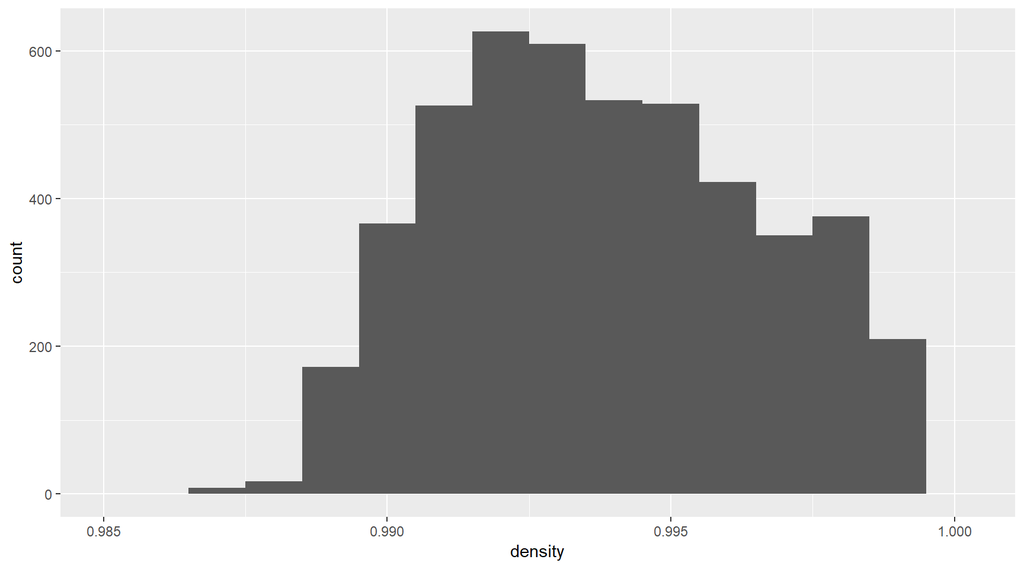

After zooming in we observe that the distribution is approx. normal, despite having uneven tail lengths.

Now, about the outliers of density.

```
##      fixed.acidity volatile.acidity citric.acid residual.sugar chlorides
## 1654           7.9            0.330        0.28           31.6     0.053
## 1664           7.9            0.330        0.28           31.6     0.053
## 2782           7.8            0.965        0.60           65.8     0.074
##      free.sulfur.dioxide total.sulfur.dioxide density   pH sulphates
## 1654                  35                  176 1.01030 3.15      0.38
## 1664                  35                  176 1.01030 3.15      0.38
## 2782                   8                  160 1.03898 3.39      0.69
##      alcohol quality bound.sulfur.dioxide
## 1654     8.8       6                  141
## 1664     8.8       6                  141
## 2782    11.7       6                  152
```

All 3 of them are of normal quality. I guess having higher densities than usual alone didn’t affect negatively to their quality too much.

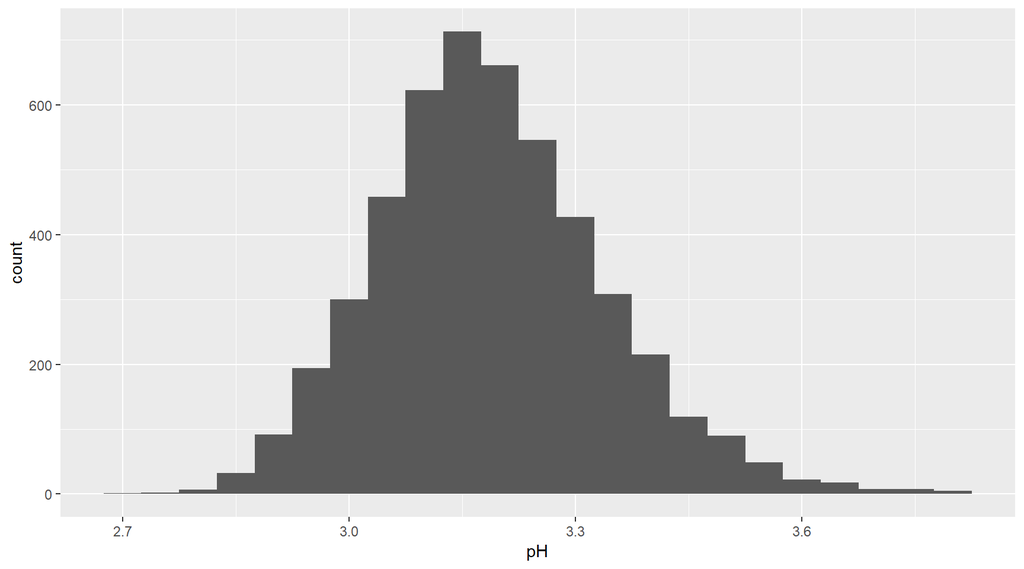

```
##    Min. 1st Qu.  Median    Mean 3rd Qu.    Max.
##   2.720   3.090   3.180   3.188   3.280   3.820
```

The pH looks normally distributed about the mean of 3.188.

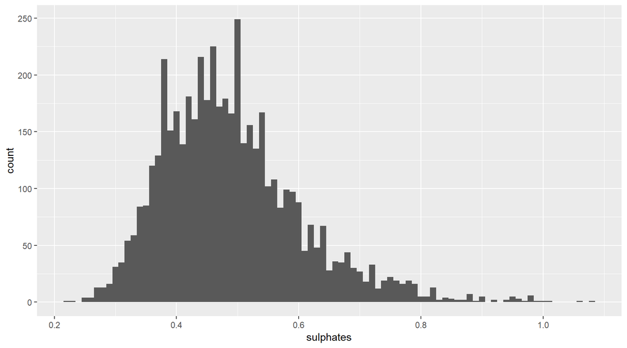

```
##    Min. 1st Qu.  Median    Mean 3rd Qu.    Max.
##  0.2200  0.4100  0.4700  0.4898  0.5500  1.0800
```

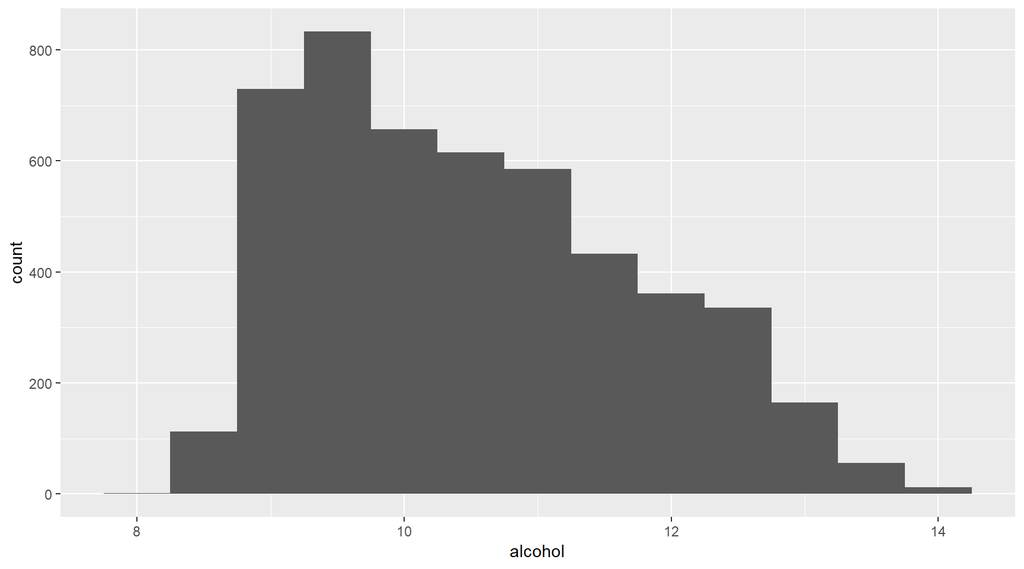

```
##    Min. 1st Qu.  Median    Mean 3rd Qu.    Max.
##    8.00    9.50   10.40   10.51   11.40   14.20
```

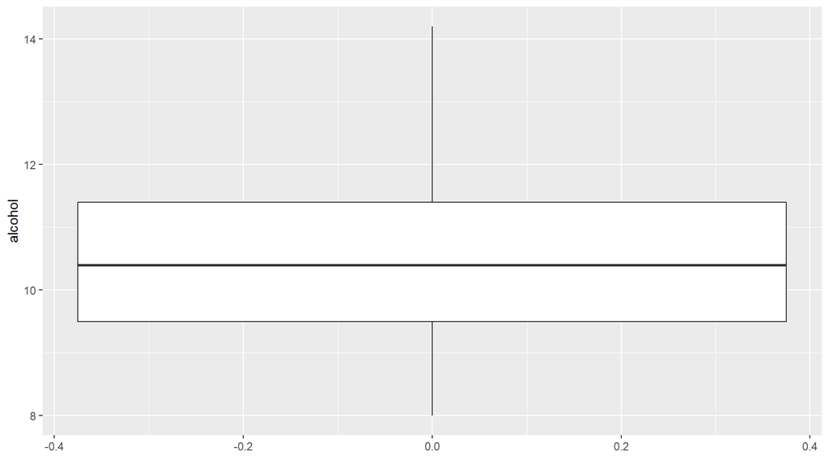

The alcohol distribution looks approximately normal with a slightly long right tail. It has a mean of 10.51.

# Univariate Analysis

### What is/are the main feature(s) of interest in your dataset?

For now, the main features will have to be quality and alcohol. I have a feeling alcohol is proportional to quality. I would like to figure out the features that are required to predict the quality of the white wine. residual.sugar also seems very interesting because of its bimodal logarithmic nature.

### What other features in the dataset do you think will help support your investigation into your feature(s) of interest?

For now I can’t rule out any of the features that might help me predict quality of the wine, but I would like to pay extra attention to sulfur dioxide contents, pH, chlorides and residual sugar.

### Did you create any new variables from existing variables in the dataset?

I created a numerical variable, bound.sulfur.dioxide. This will help me track the remaining sulfur dioxide in the wine besides free.sulfur.dioxide.

I also plan to create a new variable quality.ord, which would be quality but as an ordinal variable, ranking 9 as the highest quality down to 3 as the lowest quality. (since that is the range of quality in our dataset)

### Of the features you investigated, were there any unusual distributions?

residual.sugar had a very long right-tail so I did a log10 transformation on it. This resulted in a bimodal graph which could signify two clear classes of wine subtypes in the dataset based on sugar content.

# Bivariate Plots Section

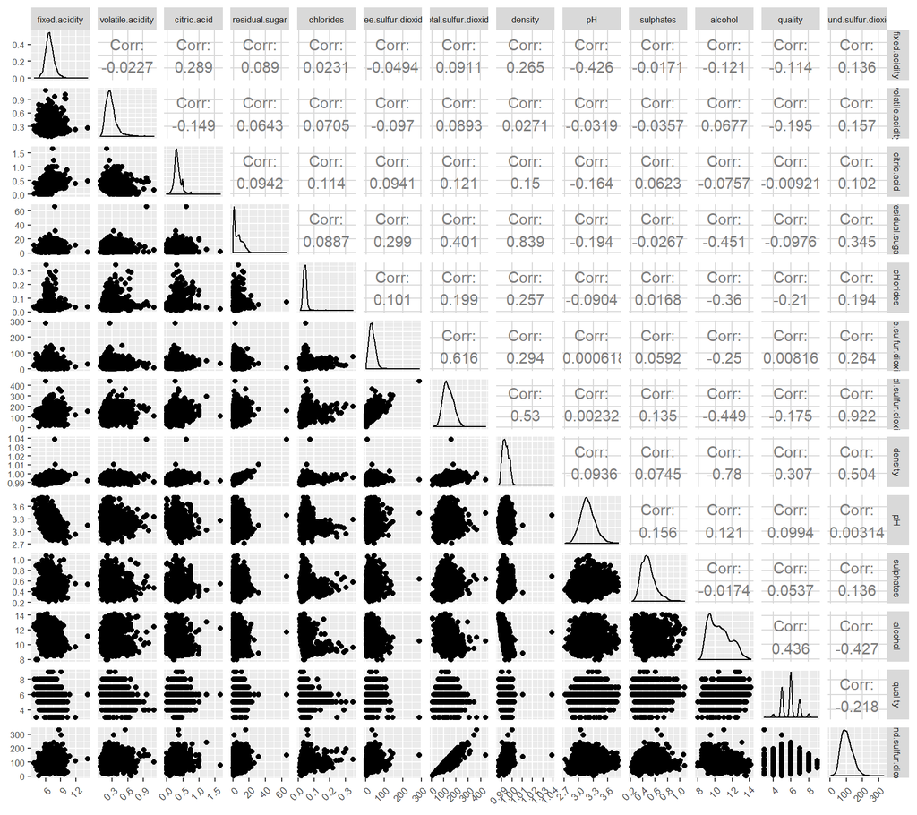

A few things to notice from here are the correlation coefficients. They give us a good indication of which bivariate relationships to focus on. Something interesting to notice is that there are only 2 meaningful correlations with “quality”:

- Quality & Alcohol : 0.436
- Quality & Density : -0.307

Neither of these can be considered as strong correlations, the one with Alcohol can be considered moderate as most.

## Main relations

‘quality.ord’ contains quality as an ordinal variable.

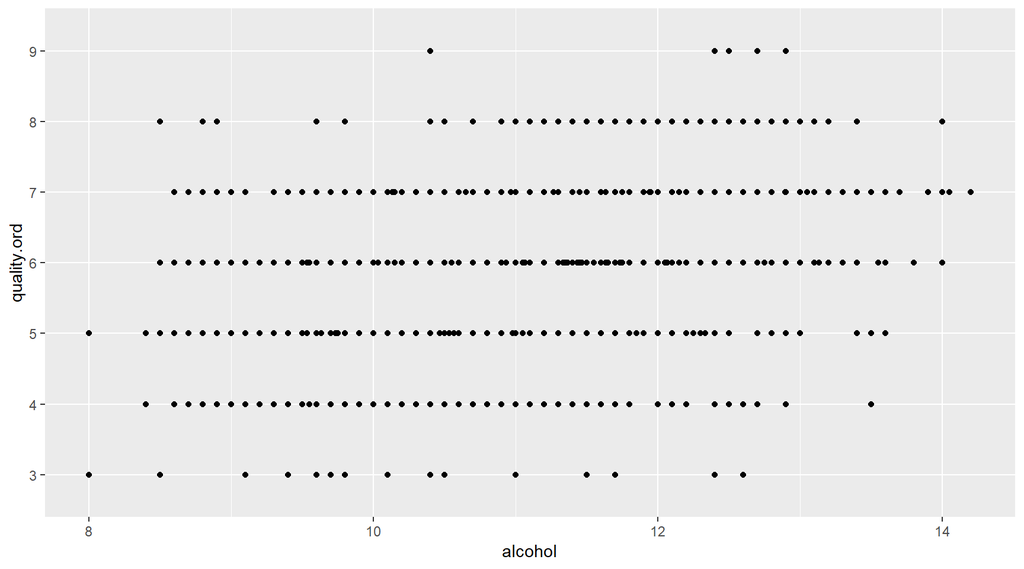

Since, quantity is a discrete value its hard for me to see a proper trend . There does seem to be a lot more points of alcohol around 11.5 the closer we get to a 6 quality but that isn’t substantial information

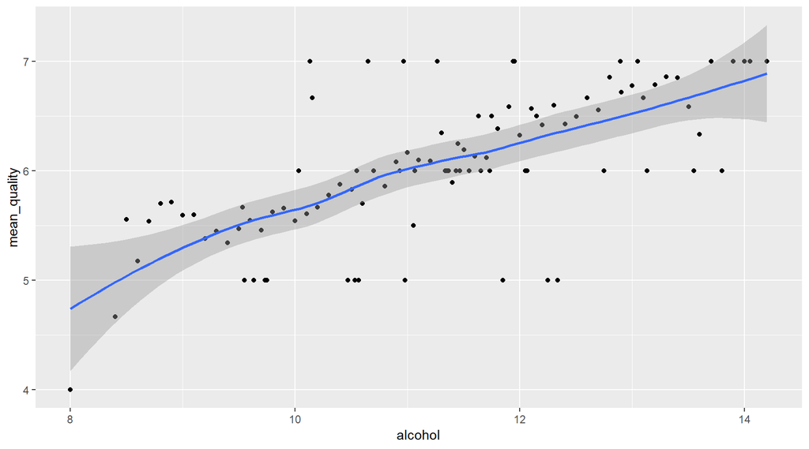

```
##
##  Pearson's product-moment correlation
##
## data:  df$alcohol and df$quality
## t = 33.858, df = 4896, p-value < 2.2e-16
## alternative hypothesis: true correlation is not equal to 0
## 95 percent confidence interval:
##  0.4126015 0.4579941
## sample estimates:
##       cor
## 0.4355747
```

This seems like a better view of the data. Here we observe a clear positive linear trend between alcohol and mean_quality with a few outliers.

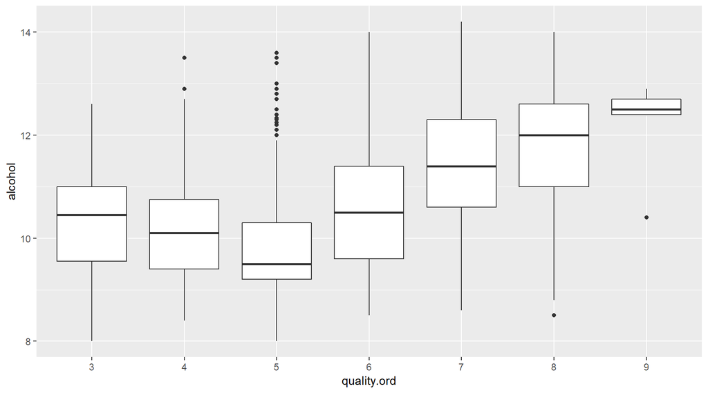

We can also see from the boxplot that the median alcohol keeps increasing as the quality increases from 5 to 9. This alongside the correlation connection between alcohol and quality.

```
##
## Call:
## lm(formula = quality ~ alcohol, data = df)
##
## Residuals:
##     Min      1Q  Median      3Q     Max
## -3.5317 -0.5286  0.0012  0.4996  3.1579
##
## Coefficients:
##             Estimate Std. Error t value Pr(>|t|)
## (Intercept) 2.582009   0.098008   26.34   <2e-16 ***
## alcohol     0.313469   0.009258   33.86   <2e-16 ***
## ---
## Signif. codes:  0 '***' 0.001 '**' 0.01 '*' 0.05 '.' 0.1 ' ' 1
##
## Residual standard error: 0.7973 on 4896 degrees of freedom
## Multiple R-squared:  0.1897, Adjusted R-squared:  0.1896
## F-statistic:  1146 on 1 and 4896 DF,  p-value: < 2.2e-16
```

Goign by the R-squared value, alcohol only explains 18.97% of the change in quality. This clearly shows that despite there being a trend between them it isn’t a very strong one.

Now let’s look at the connection between quality and density:

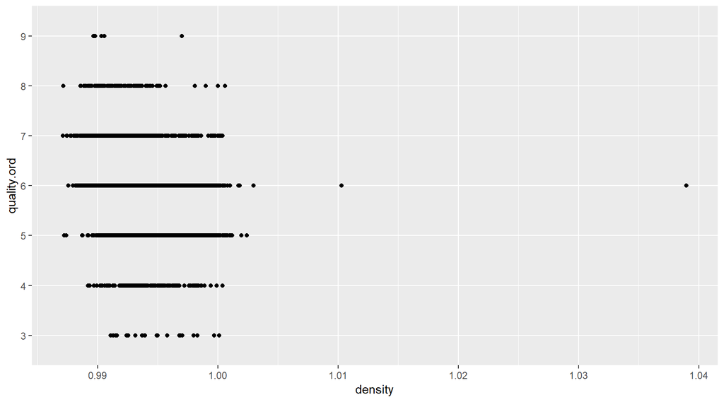

Let’s remove the outliers by limiting the x-axis to remove the top 1% of data and add some jitter.

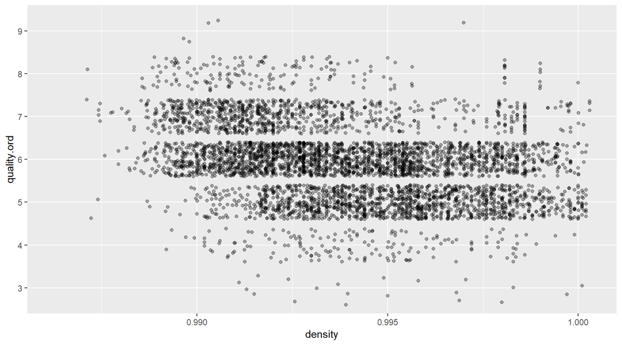

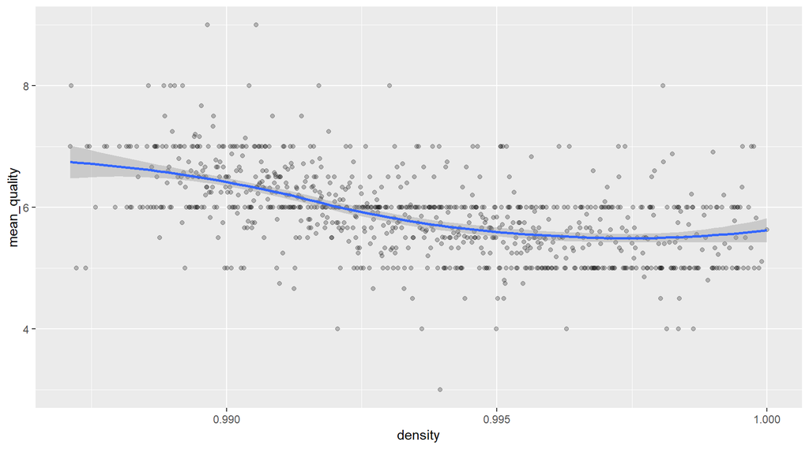

```
##
##  Pearson's product-moment correlation
##
## data:  df$density and df$quality
## t = -22.581, df = 4896, p-value < 2.2e-16
## alternative hypothesis: true correlation is not equal to 0
## 95 percent confidence interval:
##  -0.3322718 -0.2815385
## sample estimates:
##        cor
## -0.3071233
```

We can clearly see in the above plots that their is a negative trend between density and quality.

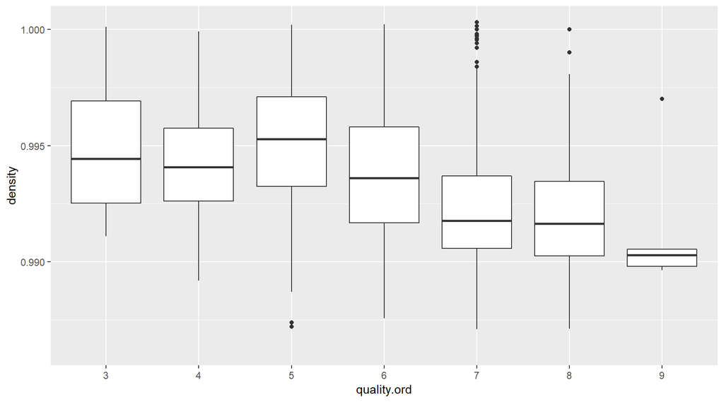

Here we observe clearly that the median density reduces as the quality increases from 5 to 9.

```
##
## Call:
## lm(formula = quality ~ density, data = df)
##
## Residuals:
##     Min      1Q  Median      3Q     Max
## -3.1441 -0.6258  0.0005  0.5162  4.2102
##
## Coefficients:
##             Estimate Std. Error t value Pr(>|t|)
## (Intercept)   96.277      4.003   24.05   <2e-16 ***
## density      -90.942      4.027  -22.58   <2e-16 ***
## ---
## Signif. codes:  0 '***' 0.001 '**' 0.01 '*' 0.05 '.' 0.1 ' ' 1
##
## Residual standard error: 0.8429 on 4896 degrees of freedom
## Multiple R-squared:  0.09432,    Adjusted R-squared:  0.09414
## F-statistic: 509.9 on 1 and 4896 DF,  p-value: < 2.2e-16
```

Despite showing presence of a clear trend density only accounts for 9.432% of the quality which is weaker than the value we got for alcohol.

Considering these were our most correlated variables with quality, it might be difficult to make a simple linear model with the variables in this dataset.

## Other relations

There are also some other correlations interrelated between our features that DO NOTE include our main feature of interest(quality). These are:

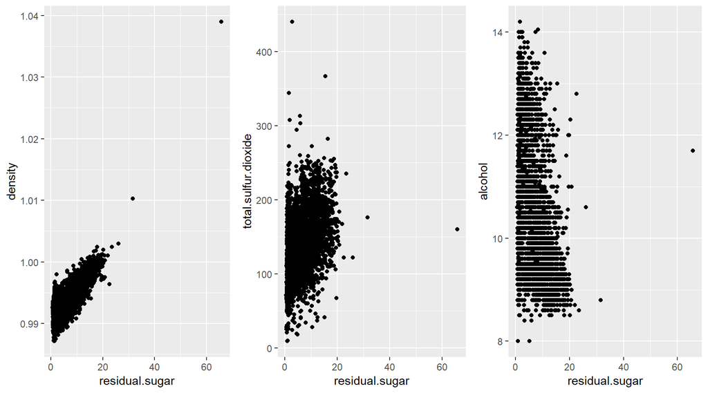

Let’s remove the outliers.

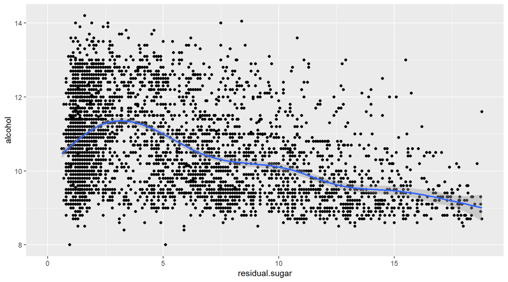

The connection between residual.sugar and alcohol doesn’t feel logical directly, maybe there is a hidden variable? Maybe density!

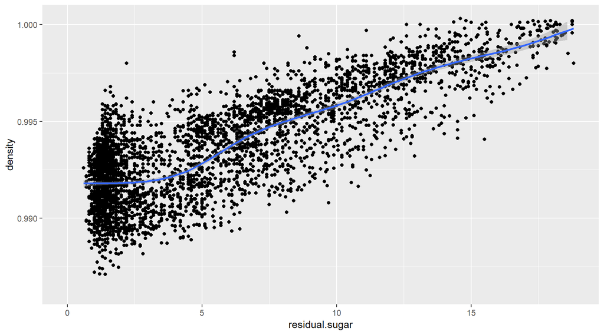

This one inherently makes sense, the more sugar in the wine, the more dense it will become!

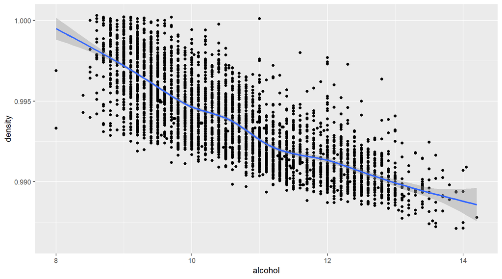

A clear negative linear trend between alcohol and density shows when alcohol increases density of the wine decreases. Maybe density is the hidden variable!